# act_report

## Report: act_report

- Create a **250-word-minimum written report** called "act_report.pdf" or "act_report.html" that communicates the insights and displays the visualization(s) produced from your wrangled data. This is to be framed as an external document, like a blog post or magazine article, for example.

### Introduction

Most people like dog pictures. They are one of the most popular content in social media. But what months are likely to have more dog pictures tweeted? What months are dog picture tweets most likely to be favorited? What does the distribution of the number of tweets by favorite count look like? We try to answer this question by examining tweet data from a popular dog picture sharing account called We Rate Dogs. In this analysis we examined the data from the period between 2015-11-15 and 2017-08-01. Only tweets with unique dog pictures were analyzed. No retweets part of this analysis.

### Analysis

- **November and December were the months with the most tweets from We Rate Dogs.**

**From the bar plot below, one can see that November and December were the month where We Rate Dogs tweeted the most dog pictures. It is probably because Thanksgiving is in November and Christmas is in December. Note that this data is from the period 2015-11-15 to 2017-08-01. Therefore, August, September and October only had one set of monthly data while all other months had two. However November and December had so many more tweets than those months that we can assume November and December have the most dog picture tweets.**

```python
#import relevant libraries
import numpy as np
import pandas as pd
import requests
import matplotlib.pyplot as plt
import seaborn as sns
```

[output not shown]

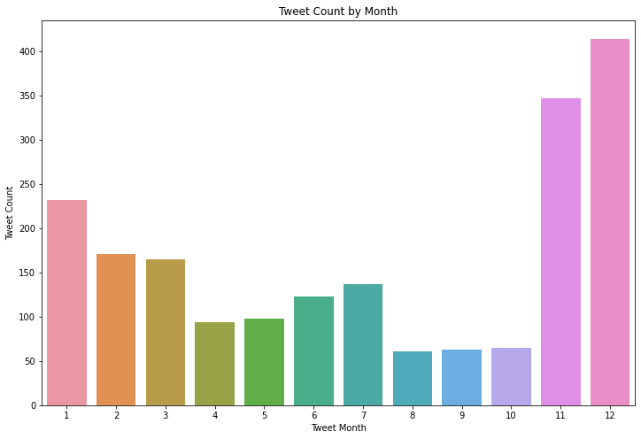

```python
#Open 'twitter_archive_master.csv' with read_csv function.
#Save it in dataframe named df_twt_arch_m
df_twt_arch_m = pd.read_csv('twitter_archive_master.csv')
#Make bar plot of tweet count by month
plt.figure(figsize=(12,8))
ax = sns.countplot(x = df_twt_arch_m.tweet_month)
ax.set(xlabel='Tweet Month', ylabel='Tweet Count', title = 'Tweet Count by Month')
```

- **October has the highest median favorite count.**

**If one looks at the boxplot below, one can see tweets of dog pictures sent in October has the highest median favorite count. This is probably because October 31st is Halloween and there are many pictures of dogs in funny costumes.**

[output not shown]

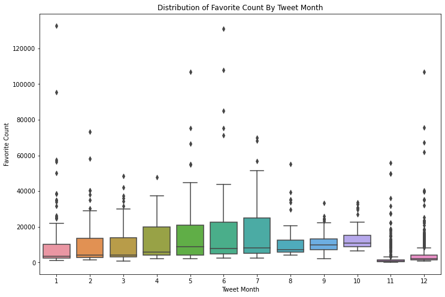

```python
#make boxplot of favorite count by tweet month
plt.figure(figsize=(12,8))
ax2 = sns.boxplot(x='tweet_month',y='favorite_count',data=df_twt_arch_m)
ax2.set(xlabel='Tweet Month', ylabel='Favorite Count', title = 'Distribution of Favorite Count By Tweet Month')
```

- **The distribution of the number of tweets by favorite count is a right skewed graph.**

**Despite We Rate Dogs having more than 9 million followers, most tweets have less than 30,000 favorite counts. We Rate Dogs founder says he considers a tweet viral if it has 30,000 favorite counts. We can see it is hard to for a dog picture tweet to go viral.**

[output not shown]

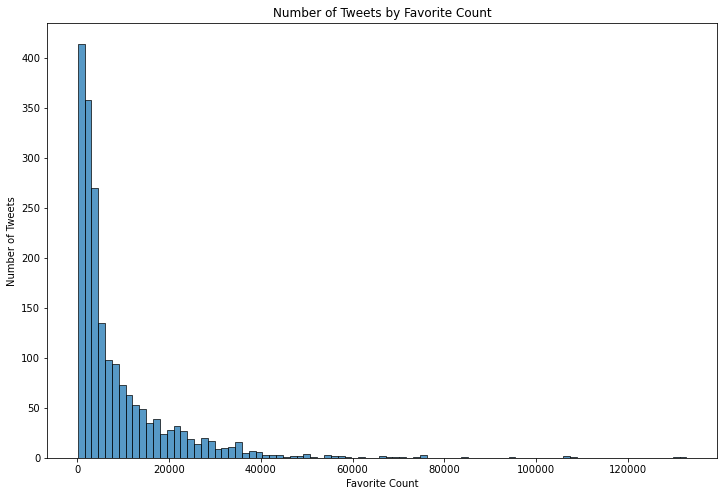

```python
#Make histogram of Number of Tweets by Favorite Count
plt.figure(figsize=(12,8))
ax1 = sns.histplot(df_twt_arch_m.favorite_count)
ax1.set(xlabel='Favorite Count', ylabel='Number of Tweets' , title = 'Number of Tweets by Favorite Count')
```

### Conclusion

- **From our data analysis of the We Rate Dogs account, more dog pictures are tweeted in November and December than other months. This is probably because Thanksgiving is in November and Christmas is in December.**
- **October has the highest median favorite count for dog picture tweets. This is probably because there are many pictures of dogs in funny costumes for Halloween.**
- **The distribution of the number of tweets by favorite count is a right skewed graph. Despite the popularity of dog pictures on social media, it is hard for a dog picture to go viral.**